# Applied Analysis

## Question 1

- What is my question and hypothesis?
- Difference between two levels?
- Difference across many different levels?
- Trends?
- Correlation?

## Question 2

- What kind of data do I have?
- Discrete
  - Success/Failure
  - Count
  - Are there a lot of zeros?
- Continuous
  - Positive only?
  - Whole real line?
  - Is it a proportion?
- Is it approximately Normal?

## Sea Cucumbers

- Want to know if they move more when there is less food, and how that varies with density.
- Positively restricted continuous variable. Might be approximately normal unless there are some zeros…

## Mean Difference:

- Big or small data set (can I rely on the central limit theorem?)
- Are the observations independent and do they have equal variance?

```r
high <- c(9.57, 16.7, 12.9, 8.95, 10.3, 9.88, 11.0)
low <- c(5.27, 5.22, 6.81, 5.62, 2.83, 4.45, 3.42)

fit.t <- t.test(high, low, alternative = "two.sided", mu = 0, paired = FALSE, var.equal = TRUE)
fit.t
```

```
##
##  Two Sample t-test
##
## data:  high and low
## t = 5.7364, df = 12, p-value = 9.361e-05
## alternative hypothesis: true difference in means is not equal to 0
## 95 percent confidence interval:
##  4.047097 9.004332
## sample estimates:
## mean of x mean of y
## 11.328571  4.802857
```

## Check Assumptions

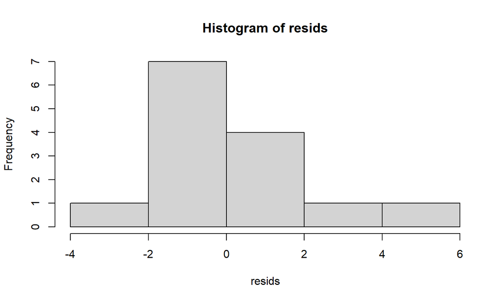

```r
  resids <- c(low - mean(low), high - mean(high))
  hist(resids)
```

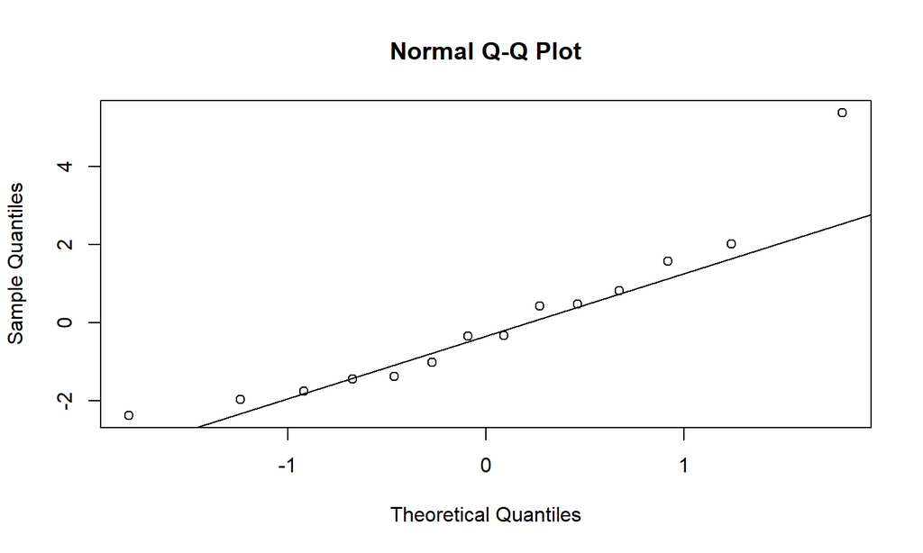

```r
  qqnorm(resids)
  qqline(resids)
```

## Reporting

- A two sample t-test was used to test the mean difference between the two groups assuming equal variances based on an F-test. We validated the test by visually inspecting the two groups for normality.
- We found that in higher concentrations of total organic material (TOM), sea cucumbers on average moved more (Mean, 95% confidence interval) 6.5 m (4.0, 9.0).

## Visualize it

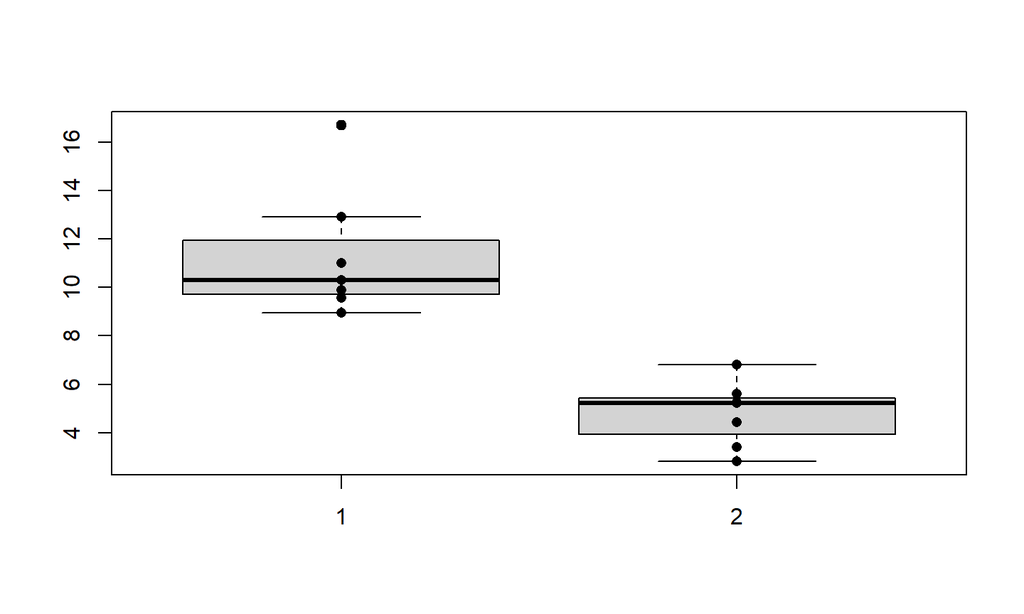

## Bad t-test

```r
grp1 <- rpois(10, 0.5)
grp2 <- rpois(10, 0.9)
t.test(grp1, grp2)
```

```
##
##  Welch Two Sample t-test
##
## data:  grp1 and grp2
## t = -1.5554, df = 17.948, p-value = 0.1373
## alternative hypothesis: true difference in means is not equal to 0
## 95 percent confidence interval:
##  -1.1754919  0.1754919
## sample estimates:
## mean of x mean of y
##       0.4       0.9
```

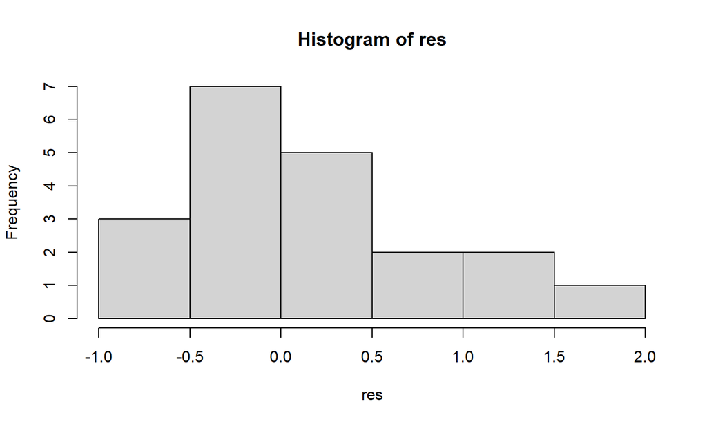

```r
  res <- c(grp1 - mean(grp1), grp2- mean(grp2))
  hist(res)
```

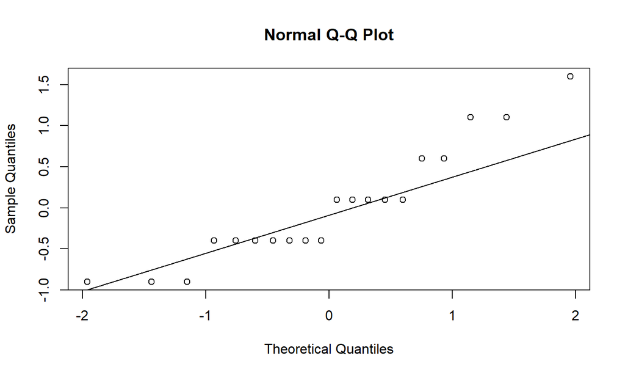

```r
  qqnorm(res)
  qqline(res)
```

## Count data difference

- Let’s assume we count the total and as a Bionimal distribution, assume that each group is equally likely.

```r
  n <- sum(c(grp1, grp2)); x1 <- sum(grp1); x2 <- sum(grp2)
  poisson.test(c(x1, x2), r = 1)
```

```
##
##  Comparison of Poisson rates
##
## data:  c(x1, x2) time base: 1
## count1 = 4, expected count1 = 6.5, p-value = 0.2668
## alternative hypothesis: true rate ratio is not equal to 1
## 95 percent confidence interval:
##  0.1000137 1.5924309
## sample estimates:
## rate ratio
##  0.4444444
```

```r
  binom.test(x1, n, p = 0.5)
```

```
##
##  Exact binomial test
##
## data:  x1 and n
## number of successes = 4, number of trials = 13, p-value = 0.2668
## alternative hypothesis: true probability of success is not equal to 0.5
## 95 percent confidence interval:
##  0.09092039 0.61426166
## sample estimates:
## probability of success
##              0.3076923
```

- Manually compute the p-value and CI

```r
  probs <- dbinom(0:n, prob = 0.5, size = n)
  sum(probs[probs <= dbinom(x1, prob = 0.5, size = n)])
```

```
## [1] 0.2668457
```

## More than one Mean to compare:

- Question 1: Is there a significant treatment effect?
- Question 2: Which treatment is having an impact?
- Example data: Sea Cucumber distance traveled for high density animals, comparing H-L, H-H, L-L.

## Analysis of Variance

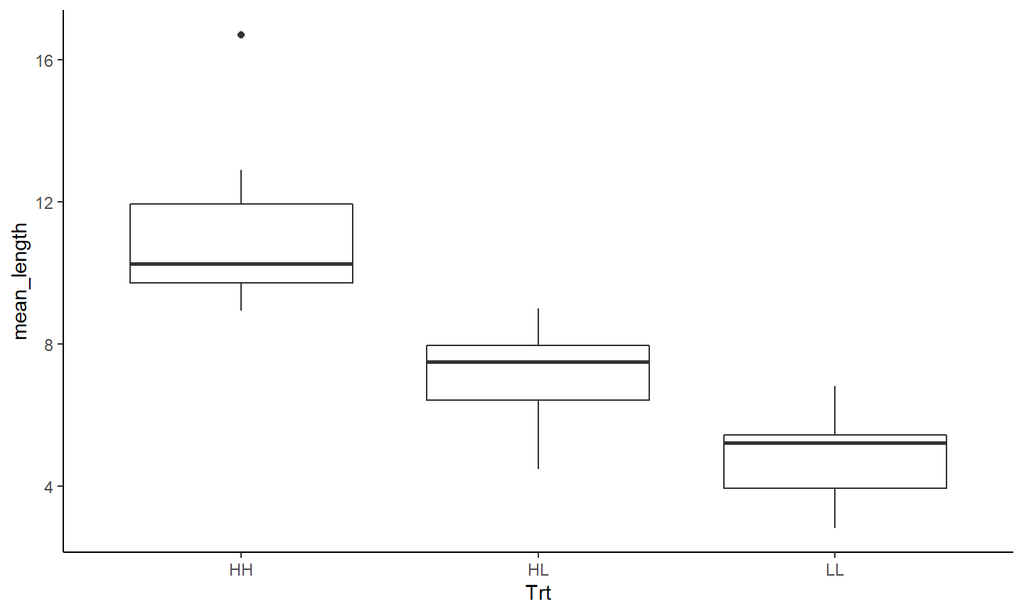

```r
  dat.cuke <- cuke.length.example %>% filter(DensHL == "H")
  ggplot(data = dat.cuke, aes(x = Trt, y = mean_length)) +
      geom_boxplot() + theme_classic()
```

## Question 1: Anything significant?

- Response Variable: \(y_i\) for \(i = 1,\ldots,n\).
- One-Way ANOVA
- Main idea: Consider Total Sum of Squares (\(SS_T\))

\[ SS_{T} = \sum_i^{n} (y_i - \bar{y}_{\cdot\cdot})^2 \]

\[ SS_{Error} = \sum_{j=1}^J\sum_i^{n} (y_i - \bar{y}_{\cdot j})^2 \]

\[ SS_{TOM} = \sum_{j=1}^J\sum_i^{n} (\bar{y}_{\cdot j} - \bar{y}_{\cdot\cdot})^2 \]

- Remember that sum of squares of normals end up \(\chi^2\) distributed.
- Ratios of \(\chi^2\) distributions end up F distributed.
- If there is a significant treatment effect,
  - the treatment variance should be LARGER than the Sum of Squared Error (residual variance).
- Assumptions
  - The observations are made from each mean group independently and with constant `white noise’ error.

\[ \begin{align} y_{ij} & = \mu + \tau_j + \epsilon_{ij} \\ \epsilon_{ij} & \sim \mathcal{N}(0, \sigma^2). \end{align} \]

## Analysis (1-way ANOVA)

```r
  fit.aov <- aov(mean_length ~ Trt, data = dat.cuke)
  summary(fit.aov)
```

```
##             Df Sum Sq Mean Sq F value   Pr(>F)
## Trt          2 152.96   76.48   20.29 2.44e-05 ***
## Residuals   18  67.85    3.77
## ---
## Signif. codes:  0 '***' 0.001 '**' 0.01 '*' 0.05 '.' 0.1 ' ' 1
```

```r
  ## Sum of Squared Error
  dat.cuke %>% group_by(Trt) %>%
    summarize(SS = sum((mean_length - mean(mean_length))^2)) %>%
    ungroup() %>% summarize(SE = sum(SS)) %>% as.numeric()
```

```
## [1] 67.84978
```

```r
  ## Sum of Squared Treatment
  dat.cuke %>% mutate(avg = mean(mean_length)) %>%
    group_by(Trt) %>%
    summarize(SS = sum((mean(mean_length) - avg)^2)) %>%
    ungroup() %>% summarize(SS = sum(SS)) %>% as.numeric()
```

```
## [1] 152.9569
```

## Is this useful?

- We just get at least one significant effect… Better to analyze the treatment effects!

```r
  em.cuke <- emmeans(fit.aov, specs = ~Trt)
  em.cuke
```

```
##  Trt emmean    SE df lower.CL upper.CL
##  HH   11.32 0.734 18     9.78    12.86
##  HL    7.11 0.734 18     5.56     8.65
##  LL    4.80 0.734 18     3.26     6.35
##
## Confidence level used: 0.95
```

## Is this useful?

```r
diff.cuke <- contrast(em.cuke, "pairwise")
diff.cuke
```

```
##  contrast estimate   SE df t.ratio p.value
##  HH - HL      4.22 1.04 18 4.062   0.0020
##  HH - LL      6.52 1.04 18 6.281   <.0001
##  HL - LL      2.30 1.04 18 2.218   0.0950
##
## P value adjustment: tukey method for comparing a family of 3 estimates
```

```r
  confint(diff.cuke)
```

```
##  contrast estimate   SE df lower.CL upper.CL
##  HH - HL      4.22 1.04 18    1.567     6.86
##  HH - LL      6.52 1.04 18    3.869     9.17
##  HL - LL      2.30 1.04 18   -0.346     4.95
##
## Confidence level used: 0.95
## Conf-level adjustment: tukey method for comparing a family of 3 estimates
```

## Is this valid?

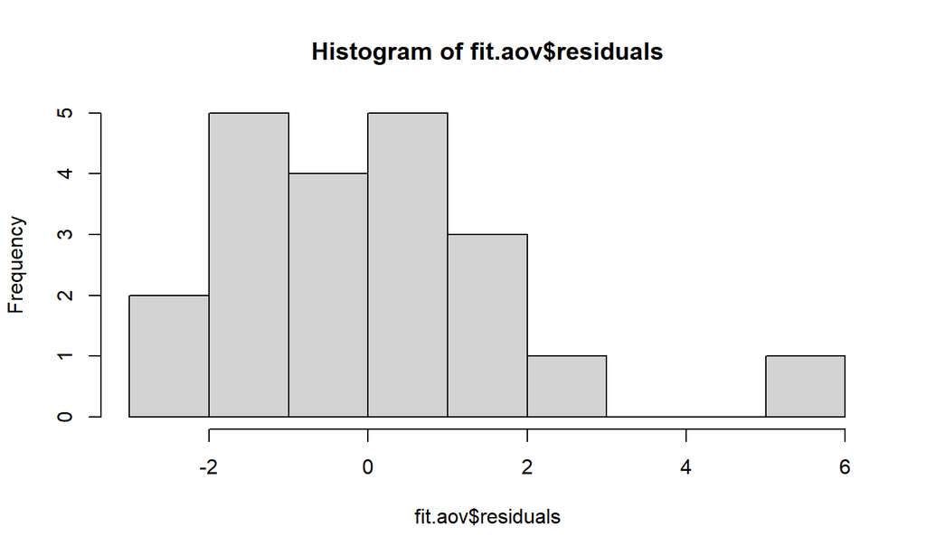

```r
  hist(fit.aov$residuals)
```

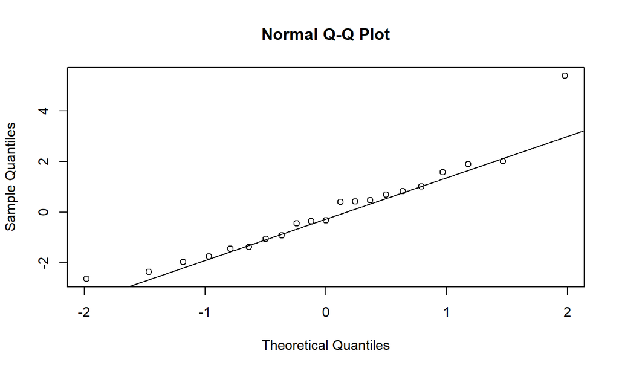

```r
  qqnorm(fit.aov$residuals)
  qqline(fit.aov$residuals)
```

## Reporting

- In analysis section: The data were analyzed for a treatment effect using an analysis of variance. We performed a residual analysis to ensure that the model assumptions were met.
- The experiments showed a very strong high TOM effect when compared with low only, animals moved 6.5 m (3.9-9.2) more on average. There was also a strong High to mixed (High-Low) TOM effect, (mean difference: 4.22 m, 1.6-6.9). There was not as much evidence for a difference between mixed and Low TOM. See Figure 1 for a comparison of the different treatments.

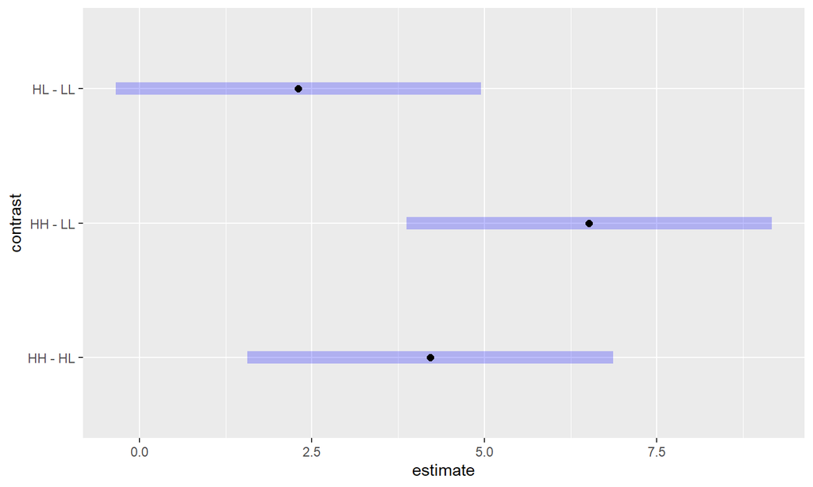

```r
  plot(diff.cuke)
```

## Analysis (2-way ANOVA)

```r
mod.aov <- aov(mean_length ~ Trt*DensHL, data = cuke.length.example)
summary(mod.aov)
```

```
##             Df Sum Sq Mean Sq F value Pr(>F)
## Trt          2  174.8   87.40   3.327 0.0472 *
## DensHL       1   68.5   68.51   2.608 0.1151
## Trt:DensHL   2   32.3   16.17   0.616 0.5460
## Residuals   36  945.8   26.27
## ---
## Signif. codes:  0 '***' 0.001 '**' 0.01 '*' 0.05 '.' 0.1 ' ' 1
```

```r
mod.aov$coefficients
```

```
##   (Intercept)         TrtHL         TrtLL       DensHLH TrtHL:DensHLH
##    12.4567643    -3.8505965    -2.6256535    -1.1353947    -0.3650299
## TrtLL:DensHLH
##    -3.8921308
```

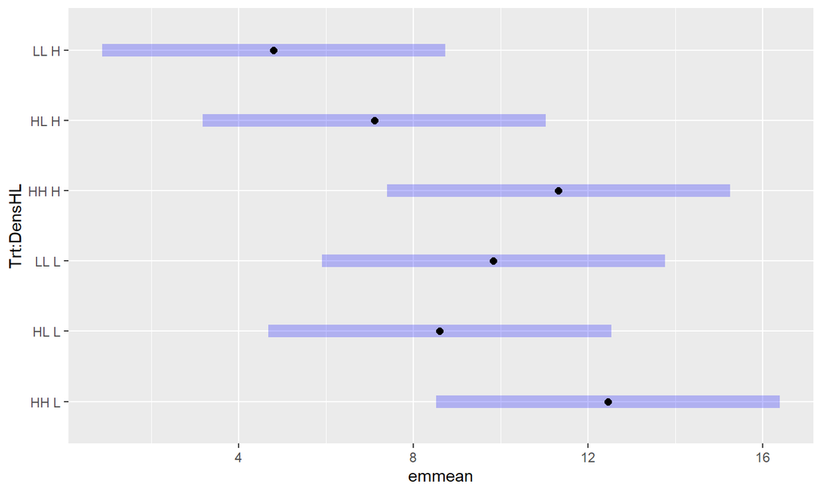

```r
em.cuke <- emmeans(mod.aov, specs = ~Trt*DensHL)
plot(em.cuke)
```

```r
contrast(em.cuke, "pairwise")
```

```
##  contrast    estimate   SE df t.ratio p.value
##  HH,L - HL,L     3.85 2.74 36  1.405  0.7235
##  HH,L - LL,L     2.63 2.74 36  0.958  0.9279
##  HH,L - HH,H     1.14 2.74 36  0.414  0.9983
##  HH,L - HL,H     5.35 2.74 36  1.953  0.3882
##  HH,L - LL,H     7.65 2.74 36  2.793  0.0817
##  HL,L - LL,L    -1.22 2.74 36 -0.447  0.9976
##  HL,L - HH,H    -2.72 2.74 36 -0.991  0.9178
##  HL,L - HL,H     1.50 2.74 36  0.548  0.9937
##  HL,L - LL,H     3.80 2.74 36  1.388  0.7338
##  LL,L - HH,H    -1.49 2.74 36 -0.544  0.9939
##  LL,L - HL,H     2.73 2.74 36  0.995  0.9166
##  LL,L - LL,H     5.03 2.74 36  1.835  0.4572
##  HH,H - HL,H     4.22 2.74 36  1.539  0.6424
##  HH,H - LL,H     6.52 2.74 36  2.379  0.1907
##  HL,H - LL,H     2.30 2.74 36  0.840  0.9578
##
## P value adjustment: tukey method for comparing a family of 6 estimates
```

```r
TukeyHSD(mod.aov)
```

```
##   Tukey multiple comparisons of means
##     95% family-wise confidence level
##
## Fit: aov(formula = mean_length ~ Trt * DensHL, data = cuke.length.example)
##
## $Trt
##             diff       lwr       upr     p adj
## HL-HH -4.0331114 -8.768568 0.7023454 0.1079099
## LL-HH -4.5717188 -9.307176 0.1637379 0.0602841
## LL-HL -0.5386074 -5.274064 4.1968494 0.9583377
##
## $DensHL
##          diff       lwr       upr    p adj
## H-L -2.554448 -5.762566 0.6536697 0.115073
##
## $`Trt:DensHL`
##                diff        lwr        upr     p adj
## HL:L-HH:L -3.850596 -12.093566  4.3923729 0.7235473
## LL:L-HH:L -2.625653 -10.868623  5.6173159 0.9279458
## HH:H-HH:L -1.135395  -9.378364  7.1075746 0.9983008
## HL:H-HH:L -5.351021 -13.593990  2.8919482 0.3881938
## LL:H-HH:L -7.653179 -15.896148  0.5897904 0.0816781
## LL:L-HL:L  1.224943  -7.018026  9.4679124 0.9975594
## HH:H-HL:L  2.715202  -5.527768 10.9581711 0.9178248
## HL:H-HL:L -1.500425  -9.743394  6.7425447 0.9936718
## LL:H-HL:L -3.802582 -12.045552  4.4403868 0.7337902
## HH:H-LL:L  1.490259  -6.752711  9.7332281 0.9938681
## HL:H-LL:L -2.725368 -10.968337  5.5176017 0.9166238
## LL:H-LL:L -5.027526 -13.270495  3.2154438 0.4571920
## HL:H-HH:H -4.215626 -12.458596  4.0273430 0.6424237
## LL:H-HH:H -6.517784 -14.760754  1.7251851 0.1907206
## LL:H-HL:H -2.302158 -10.545127  5.9408115 0.9577891
```

## Is it valid?

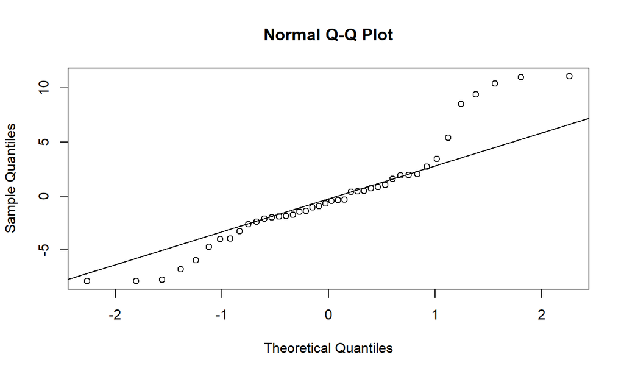

```r
  resid <- mod.aov$residuals
  qqnorm(resid)
  qqline(resid)
```

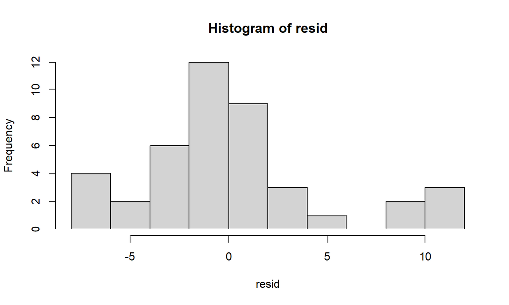

```r
  hist(resid)
```

## Maybe a transformation is better?

```r
mod.aov2 <- aov(log(mean_length) ~ Trt*DensHL, data = cuke.length.example)
summary(mod.aov2)
```

```
##             Df Sum Sq Mean Sq F value Pr(>F)
## Trt          2  2.506  1.2532   4.192 0.0231 *
## DensHL       1  0.227  0.2270   0.759 0.3893
## Trt:DensHL   2  0.682  0.3412   1.141 0.3307
## Residuals   36 10.763  0.2990
## ---
## Signif. codes:  0 '***' 0.001 '**' 0.01 '*' 0.05 '.' 0.1 ' ' 1
```

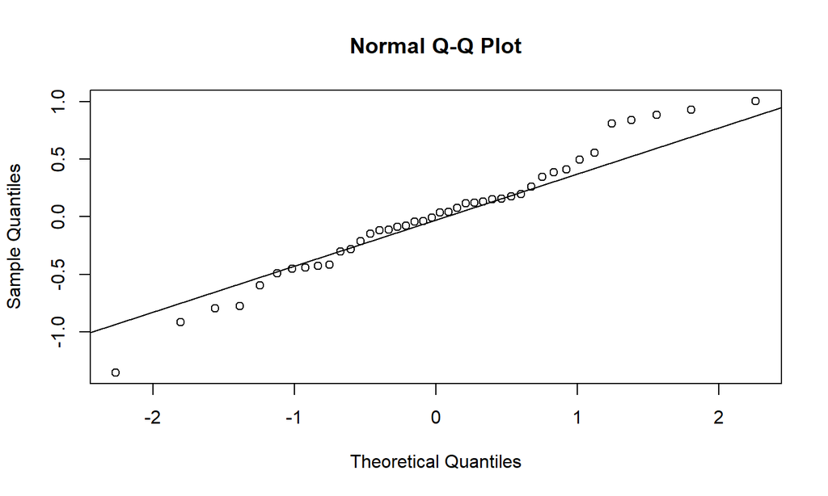

```r
   qqnorm(mod.aov2$residuals)
   qqline(mod.aov2$residuals)
```

## Interpreting new results?

```r
emmeans(mod.aov2, specs = ~Trt*DensHL)
```

```
##  Trt DensHL emmean    SE df lower.CL upper.CL
##  HH  L        2.32 0.207 36     1.90     2.74
##  HL  L        1.96 0.207 36     1.54     2.38
##  LL  L        2.03 0.207 36     1.62     2.45
##  HH  H        2.41 0.207 36     1.99     2.82
##  HL  H        1.94 0.207 36     1.52     2.36
##  LL  H        1.53 0.207 36     1.11     1.95
##
## Results are given on the log (not the response) scale.
## Confidence level used: 0.95
```

```r
emmeans(mod.aov2, specs = ~Trt*DensHL, type = 'response')
```

```
##  Trt DensHL response    SE df lower.CL upper.CL
##  HH  L         10.21 2.109 36     6.71    15.52
##  HL  L          7.10 1.468 36     4.67    10.80
##  LL  L          7.65 1.580 36     5.03    11.63
##  HH  H         11.08 2.291 36     7.29    16.85
##  HL  H          6.96 1.438 36     4.57    10.58
##  LL  H          4.63 0.956 36     3.04     7.03
##
## Confidence level used: 0.95
## Intervals are back-transformed from the log scale
```

## ANOVA as a LM

- Factor 1: TOM HH, HL, LL
- Factor 2: Dens H, L \[ \begin{align} y_{ij} & = \beta_0 + \beta_1 (HL) + \beta_2(LL) + \beta_3(DensH) + \beta_4 (DensH \times HL) + \\ & \beta_5(DensH\times LL) + \epsilon_{ij} \\ \epsilon_{ij} & \sim \mathcal{N}(0, \sigma^2). \end{align} \]

```r
model.matrix(mean_length ~ Trt*DensHL, data = cuke.length.example)
```

```
##    (Intercept) TrtHL TrtLL DensHLH TrtHL:DensHLH TrtLL:DensHLH
## 1            1     1     0       0             0             0
## 2            1     0     1       0             0             0
## 3            1     1     0       1             1             0
## 4            1     0     1       1             0             1
## 5            1     0     0       1             0             0
## 6            1     0     0       0             0             0
## 7            1     0     0       1             0             0
## 8            1     1     0       1             1             0
## 9            1     0     0       0             0             0
## 10           1     0     1       0             0             0
## 11           1     1     0       0             0             0
## 12           1     0     1       1             0             1
## 13           1     0     0       1             0             0
## 14           1     1     0       0             0             0
```

[output cut: 36 more lines]

## ANOVA as LM

```r
fit.lm <- lm(log(mean_length) ~ Trt*DensHL, data = cuke.length.example)
```

[output not shown]

## Summarizing in an ANOVA way.

```r
  anova(fit.lm)
```

```
## Analysis of Variance Table
##
## Response: log(mean_length)
##            Df  Sum Sq Mean Sq F value  Pr(>F)
## Trt         2  2.5064 1.25320  4.1918 0.02309 *
## DensHL      1  0.2270 0.22699  0.7592 0.38934
## Trt:DensHL  2  0.6824 0.34122  1.1413 0.33068
## Residuals  36 10.7627 0.29896
## ---
## Signif. codes:  0 '***' 0.001 '**' 0.01 '*' 0.05 '.' 0.1 ' ' 1
```

## Basic T Test as an LM

```r
  datHL <- data.frame(trt = rep(c("H", "L"), each = 7), length = c(high, low))
  t.test(high, low, var.equal = TRUE)
```

```
##
##  Two Sample t-test
##
## data:  high and low
## t = 5.7364, df = 12, p-value = 9.361e-05
## alternative hypothesis: true difference in means is not equal to 0
## 95 percent confidence interval:
##  4.047097 9.004332
## sample estimates:
## mean of x mean of y
## 11.328571  4.802857
```

## Basic T Test as an LM

```r
  fit.t <- lm(length ~  trt, data = datHL)
  summary(fit.t)
```

```
##
## Call:
## lm(formula = length ~ trt, data = datHL)
##
## Residuals:
##     Min      1Q  Median      3Q     Max
## -2.3786 -1.4321 -0.3407  0.7296  5.3714
##
## Coefficients:
##             Estimate Std. Error t value Pr(>|t|)
## (Intercept)  11.3286     0.8044  14.083 7.98e-09 ***
## trtL         -6.5257     1.1376  -5.736 9.36e-05 ***
## ---
## Signif. codes:  0 '***' 0.001 '**' 0.01 '*' 0.05 '.' 0.1 ' ' 1
##
## Residual standard error: 2.128 on 12 degrees of freedom
## Multiple R-squared:  0.7328, Adjusted R-squared:  0.7105
## F-statistic: 32.91 on 1 and 12 DF,  p-value: 9.361e-05
```

## Next Steps

- Nearly everything is a ‘linear’ model.
- We will not use the aov function anymore, but instead us lm() or later glm()
- We will then distinguish between continuous covariates that fit an actual ‘slope’ vs categorical variables that are coded as a ‘factor’ in R.